# CS02 - Predicting Annual Air Pollution

Jonathan Ito, Qinwen Deng, Chunjiang Liu, Jessica De La Torre, William Zhao

## Introduction

Throughout the U.S., air pollution has been an increasingly alarming issue, as different pollutants become more prominent . Currently, air pollutants can be divided into four different categories and three different particulates. The type categories include: gaseous, particulate, dust, and biological. These particulate categories are the following: large coarse particulates (diameter greater than 10 µm), coarse particulate matter (diameter between 2.5-10 µm), and fine particulate matter (diameter less than 2.5 µm) (COGS 137 - Lecture: 09-cs02-intro; U.S. Environmental Protection Agency). From these categories, fine particulate matter poses the greatest health threat. Fine particles are the most harmful from the three due to the fact that they are more easily absorbed into the body, to the point where they can go so far as to be penetrated into the lung alveoli (COGS 137 - Lecture: 09-cs02-intro; Manisalidis et al.). Regardless of size, air pollution has the potential to damage one’s health significantly. Specifically, exposure to air pollution can lead to a variety of conditions including asthma, inflammation in type 1 diabetes, viral infections, and in extreme cases even death (COGS 137 - Lecture: 09-cs02-intro; Puett et al.). Thus, it is important to gather information about these types of air pollution and how they affect the people that are faced with air pollution in their communities.

In past studies, the effects of pollution on communities have previously been studied, yet there are still some issues with the methods and limitations. A notable issue is that the monitors that are used to track air pollution are placed in limited locations across the U.S., especially within cities. This is an issue because significant changes in air pollution can be noticed in micro-environments within the same city (COGS 137 - Lecture: 09-cs02-intro; Yanosky et al.). However, in this study, the intention is to understand with what accuracy can machine learning help us predict the U.S. annual average air pollution concentrations. It is understood that machine learning can help overcome the sparsity of monitors across the U.S. In doing this, we can account for the lack of data in micro-environments, and collect a more comprehensive understanding of air pollution rates across the U.S. To address these limitations, this study leverages machine learning to predict U.S. annual average air pollution concentrations and explores how accurately these predictions can be made. Additionally, it examines how prediction accuracy differs between Random Forest and Linear Regression models in counties with high and low population densities.

## Questions

### Main Question

With what accuracy can we predict US annual average air pollution concentrations?

### Extension Question

How does the prediction accuracy differ in counties with high and low population densities when using a Random Forest prediction model versus a Linear prediction model?

### Load packages

```r
library(tidymodels)
library(tidyverse)
library(skimr)
library(GGally)
```

## The Data

The dataset is retrieved from Open Case Studies: Predicting Annual Air Pollution (Wright et al., 2020). The dataset contains air pollution measurements from the US Environmental Protection Agency (EPA) and several other sources, including NASA, the US Census, and the National Center for Health Statistics (NCHS). It includes data from 876 monitors across the contiguous United States, each providing annual averages of fine particulate matter (PM2.5) concentration, measured in micrograms per cubic meter (µg/m³). The outcome variable is the PM2.5 concentration, captured by gravimetric monitors, which are equipped with filtration systems that specifically measure fine particulate matter.

In addition to the monitor data, the dataset includes a variety of predictor variables, including geographical data (latitude, longitude, and FIPS code), demographic data (population density, educational attainment, and poverty levels), environmental data (impervious surface measures and proximity to primary and secondary roads), satellite-based data (aerosol optical depth (AOD) measurements from NASA, a proxy for particulate pollution), and other variables (proximity to major emission sources and county-level urban-rural classification).

### Data Import

```r
pm <- read_csv("data/pm25_data.csv")
```

### Data Wrangling

Some of the variables don’t have very informative names, so as part of the data wrangling we will be renaming those variables.

```r
pm <- pm |>
  rename(impervious_surface_500 = imp_a500,
         impervious_surface_1000 = imp_a1000,
         impervious_surface_5000 = imp_a5000,
         impervious_surface_10000 = imp_a10000,
         impervious_surface_15000 = imp_a15000,

         log_pm25_emmissions_10000 = log_nei_2008_pm25_sum_10000,
         log_pm25_emmissions_15000 = log_nei_2008_pm25_sum_15000,
         log_pm25_emmissions_25000 = log_nei_2008_pm25_sum_25000,
         log_pm10_emmissions_10000 = log_nei_2008_pm10_sum_10000,
         log_pm10_emmissions_15000 = log_nei_2008_pm10_sum_15000,
         log_pm10_emmissions_25000 = log_nei_2008_pm10_sum_25000,

         urban_level_2013 = urc2013,
         urban_level_2006 = urc2006)
```

We also want to make sure that the data is in the right format. We need some of our data to be factors, so let’s do that.

```r
pm <- pm |>
  mutate(across(c(id, fips, zcta), as.factor))
```

Lastly, we’re gonna want a long version of our dataset in order to generate some plots, so we’ll make that now.

```r
pm_long <- pm |>
  pivot_longer(cols = starts_with("impervious"),
               names_to = "impervious_surfaces",
               values_to = "impervious_surfaces_values") |>
  pivot_longer(cols = starts_with("log_pri_"),
               names_to = "pri_roads",
               values_to = "pri_roads_values") |>
  pivot_longer(cols = starts_with("log_prisec"),
               names_to = "prisec_roads",
               values_to = "prisec_roads_values") |>
  pivot_longer(cols = starts_with("log_pm"),
               names_to = "pm_emissions",
               values_to = "pm_emissions_values")

pm_long
```

```
## # A tibble: 630,720 × 37
##    id       value fips    lat   lon state   county  city    CMAQ zcta  zcta_area
##    <fct>    <dbl> <fct> <dbl> <dbl> <chr>   <chr>   <chr>  <dbl> <fct>     <dbl>
##  1 1003.001  9.60 1003   30.5 -87.9 Alabama Baldwin Fairh…  8.10 36532 190980522
##  2 1003.001  9.60 1003   30.5 -87.9 Alabama Baldwin Fairh…  8.10 36532 190980522
##  3 1003.001  9.60 1003   30.5 -87.9 Alabama Baldwin Fairh…  8.10 36532 190980522
##  4 1003.001  9.60 1003   30.5 -87.9 Alabama Baldwin Fairh…  8.10 36532 190980522
##  5 1003.001  9.60 1003   30.5 -87.9 Alabama Baldwin Fairh…  8.10 36532 190980522
##  6 1003.001  9.60 1003   30.5 -87.9 Alabama Baldwin Fairh…  8.10 36532 190980522
##  7 1003.001  9.60 1003   30.5 -87.9 Alabama Baldwin Fairh…  8.10 36532 190980522
##  8 1003.001  9.60 1003   30.5 -87.9 Alabama Baldwin Fairh…  8.10 36532 190980522
##  9 1003.001  9.60 1003   30.5 -87.9 Alabama Baldwin Fairh…  8.10 36532 190980522
## 10 1003.001  9.60 1003   30.5 -87.9 Alabama Baldwin Fairh…  8.10 36532 190980522
## # ℹ 630,710 more rows
## # ℹ 26 more variables: zcta_pop <dbl>, county_area <dbl>, county_pop <dbl>,
## #   log_dist_to_prisec <dbl>, popdens_county <dbl>, popdens_zcta <dbl>,
## #   nohs <dbl>, somehs <dbl>, hs <dbl>, somecollege <dbl>, associate <dbl>,
## #   bachelor <dbl>, grad <dbl>, pov <dbl>, hs_orless <dbl>,
## #   urban_level_2013 <dbl>, urban_level_2006 <dbl>, aod <dbl>,
## #   impervious_surfaces <chr>, impervious_surfaces_values <dbl>, …
```

## EDA

The first thing we would like to do is just get an overall look at the data, and to do that we will use skimr. This function gives us some quick, but important, statistics about our data that can be very useful for the rest of the EDA and Analysis that we do.

```r
skim(pm)
```

Data summary

| Name | pm |
| --- | --- |
| Number of rows | 876 |
| Number of columns | 50 |
| _______________________ |  |
| Column type frequency: |  |
| character | 3 |
| factor | 3 |
| numeric | 44 |
| ________________________ |  |
| Group variables | None |

**Variable type: character**

| skim_variable | n_missing | complete_rate | min | max | empty | n_unique | whitespace |
| --- | --- | --- | --- | --- | --- | --- | --- |
| state | 0 | 1 | 4 | 20 | 0 | 49 | 0 |
| county | 0 | 1 | 3 | 20 | 0 | 471 | 0 |
| city | 0 | 1 | 4 | 48 | 0 | 607 | 0 |

**Variable type: factor**

| skim_variable | n_missing | complete_rate | ordered | n_unique | top_counts |
| --- | --- | --- | --- | --- | --- |
| id | 0 | 1 | FALSE | 876 | 100: 1, 102: 1, 103: 1, 104: 1 |
| fips | 0 | 1 | FALSE | 569 | 170: 12, 603: 10, 261: 9, 107: 8 |
| zcta | 0 | 1 | FALSE | 842 | 475: 3, 110: 2, 160: 2, 290: 2 |

**Variable type: numeric**

| skim_variable | n_missing | complete_rate | mean | sd | p0 | p25 | p50 | p75 | p100 | hist |
| --- | --- | --- | --- | --- | --- | --- | --- | --- | --- | --- |
| value | 0 | 1 | 10.81 | 2.580000e+00 | 3.02 | 9.27 | 11.15 | 12.37 | 2.316000e+01 | ▂▆▇▁▁ |
| lat | 0 | 1 | 38.48 | 4.620000e+00 | 25.47 | 35.03 | 39.30 | 41.66 | 4.840000e+01 | ▁▃▅▇▂ |
| lon | 0 | 1 | -91.74 | 1.496000e+01 | -124.18 | -99.16 | -87.47 | -80.69 | -6.804000e+01 | ▃▂▃▇▃ |
| CMAQ | 0 | 1 | 8.41 | 2.970000e+00 | 1.63 | 6.53 | 8.62 | 10.24 | 2.313000e+01 | ▃▇▃▁▁ |
| zcta_area | 0 | 1 | 183173481.91 | 5.425989e+08 | 15459.00 | 14204601.75 | 37653560.50 | 160041508.25 | 8.164821e+09 | ▇▁▁▁▁ |
| zcta_pop | 0 | 1 | 24227.58 | 1.777216e+04 | 0.00 | 9797.00 | 22014.00 | 35004.75 | 9.539700e+04 | ▇▇▃▁▁ |
| impervious_surface_500 | 0 | 1 | 24.72 | 1.934000e+01 | 0.00 | 3.70 | 25.12 | 40.22 | 6.961000e+01 | ▇▅▆▃▂ |
| impervious_surface_1000 | 0 | 1 | 24.26 | 1.802000e+01 | 0.00 | 5.32 | 24.53 | 38.59 | 6.750000e+01 | ▇▅▆▃▁ |
| impervious_surface_5000 | 0 | 1 | 19.93 | 1.472000e+01 | 0.05 | 6.79 | 19.07 | 30.11 | 7.460000e+01 | ▇▆▃▁▁ |
| impervious_surface_10000 | 0 | 1 | 15.82 | 1.381000e+01 | 0.09 | 4.54 | 12.36 | 24.17 | 7.209000e+01 | ▇▃▂▁▁ |
| impervious_surface_15000 | 0 | 1 | 13.43 | 1.312000e+01 | 0.11 | 3.24 | 9.67 | 20.55 | 7.110000e+01 | ▇▃▁▁▁ |
| county_area | 0 | 1 | 3768701992.12 | 6.212830e+09 | 33703512.00 | 1116536297.50 | 1690826566.50 | 2878192209.00 | 5.194723e+10 | ▇▁▁▁▁ |
| county_pop | 0 | 1 | 687298.44 | 1.293489e+06 | 783.00 | 100948.00 | 280730.50 | 743159.00 | 9.818605e+06 | ▇▁▁▁▁ |
| log_dist_to_prisec | 0 | 1 | 6.19 | 1.410000e+00 | -1.46 | 5.43 | 6.36 | 7.15 | 1.045000e+01 | ▁▁▃▇▁ |
| log_pri_length_5000 | 0 | 1 | 9.82 | 1.080000e+00 | 8.52 | 8.52 | 10.05 | 10.73 | 1.205000e+01 | ▇▂▆▅▂ |
| log_pri_length_10000 | 0 | 1 | 10.92 | 1.130000e+00 | 9.21 | 9.80 | 11.17 | 11.83 | 1.302000e+01 | ▇▂▇▇▃ |
| log_pri_length_15000 | 0 | 1 | 11.50 | 1.150000e+00 | 9.62 | 10.87 | 11.72 | 12.40 | 1.359000e+01 | ▆▂▇▇▃ |
| log_pri_length_25000 | 0 | 1 | 12.24 | 1.100000e+00 | 10.13 | 11.69 | 12.46 | 13.05 | 1.436000e+01 | ▅▃▇▇▃ |
| log_prisec_length_500 | 0 | 1 | 6.99 | 9.500000e-01 | 6.21 | 6.21 | 6.21 | 7.82 | 9.400000e+00 | ▇▁▂▂▁ |
| log_prisec_length_1000 | 0 | 1 | 8.56 | 7.900000e-01 | 7.60 | 7.60 | 8.66 | 9.20 | 1.047000e+01 | ▇▅▆▃▁ |
| log_prisec_length_5000 | 0 | 1 | 11.28 | 7.800000e-01 | 8.52 | 10.91 | 11.42 | 11.83 | 1.278000e+01 | ▁▁▃▇▃ |
| log_prisec_length_10000 | 0 | 1 | 12.41 | 7.300000e-01 | 9.21 | 11.99 | 12.53 | 12.94 | 1.385000e+01 | ▁▁▃▇▅ |
| log_prisec_length_15000 | 0 | 1 | 13.03 | 7.200000e-01 | 9.62 | 12.59 | 13.13 | 13.57 | 1.441000e+01 | ▁▁▃▇▅ |
| log_prisec_length_25000 | 0 | 1 | 13.82 | 7.000000e-01 | 10.13 | 13.38 | 13.92 | 14.35 | 1.523000e+01 | ▁▁▃▇▆ |
| log_pm25_emmissions_10000 | 0 | 1 | 3.97 | 2.350000e+00 | 0.00 | 2.15 | 4.29 | 5.69 | 9.120000e+00 | ▆▅▇▆▂ |
| log_pm25_emmissions_15000 | 0 | 1 | 4.72 | 2.250000e+00 | 0.00 | 3.47 | 5.00 | 6.35 | 9.420000e+00 | ▃▃▇▇▂ |
| log_pm25_emmissions_25000 | 0 | 1 | 5.67 | 2.110000e+00 | 0.00 | 4.66 | 5.91 | 7.28 | 9.650000e+00 | ▂▂▇▇▃ |
| log_pm10_emmissions_10000 | 0 | 1 | 4.35 | 2.320000e+00 | 0.00 | 2.69 | 4.62 | 6.07 | 9.340000e+00 | ▅▅▇▇▂ |
| log_pm10_emmissions_15000 | 0 | 1 | 5.10 | 2.180000e+00 | 0.00 | 3.87 | 5.39 | 6.72 | 9.710000e+00 | ▂▃▇▇▂ |
| log_pm10_emmissions_25000 | 0 | 1 | 6.07 | 2.010000e+00 | 0.00 | 5.10 | 6.37 | 7.52 | 9.880000e+00 | ▁▂▆▇▃ |
| popdens_county | 0 | 1 | 551.76 | 1.711510e+03 | 0.26 | 40.77 | 156.67 | 510.81 | 2.682191e+04 | ▇▁▁▁▁ |
| popdens_zcta | 0 | 1 | 1279.66 | 2.757490e+03 | 0.00 | 101.15 | 610.35 | 1382.52 | 3.041884e+04 | ▇▁▁▁▁ |
| nohs | 0 | 1 | 6.99 | 7.210000e+00 | 0.00 | 2.70 | 5.10 | 8.80 | 1.000000e+02 | ▇▁▁▁▁ |
| somehs | 0 | 1 | 10.17 | 6.200000e+00 | 0.00 | 5.90 | 9.40 | 13.90 | 7.220000e+01 | ▇▂▁▁▁ |
| hs | 0 | 1 | 30.32 | 1.140000e+01 | 0.00 | 23.80 | 30.75 | 36.10 | 1.000000e+02 | ▂▇▂▁▁ |
| somecollege | 0 | 1 | 21.58 | 8.600000e+00 | 0.00 | 17.50 | 21.30 | 24.70 | 1.000000e+02 | ▆▇▁▁▁ |
| associate | 0 | 1 | 7.13 | 4.010000e+00 | 0.00 | 4.90 | 7.10 | 8.80 | 7.140000e+01 | ▇▁▁▁▁ |
| bachelor | 0 | 1 | 14.90 | 9.710000e+00 | 0.00 | 8.80 | 12.95 | 19.22 | 1.000000e+02 | ▇▂▁▁▁ |
| grad | 0 | 1 | 8.91 | 8.650000e+00 | 0.00 | 3.90 | 6.70 | 11.00 | 1.000000e+02 | ▇▁▁▁▁ |
| pov | 0 | 1 | 14.95 | 1.133000e+01 | 0.00 | 6.50 | 12.10 | 21.22 | 6.590000e+01 | ▇▅▂▁▁ |
| hs_orless | 0 | 1 | 47.48 | 1.675000e+01 | 0.00 | 37.92 | 48.65 | 59.10 | 1.000000e+02 | ▁▃▇▃▁ |
| urban_level_2013 | 0 | 1 | 2.92 | 1.520000e+00 | 1.00 | 2.00 | 3.00 | 4.00 | 6.000000e+00 | ▇▅▃▂▁ |
| urban_level_2006 | 0 | 1 | 2.97 | 1.520000e+00 | 1.00 | 2.00 | 3.00 | 4.00 | 6.000000e+00 | ▇▅▃▂▁ |
| aod | 0 | 1 | 43.70 | 1.956000e+01 | 5.00 | 31.66 | 40.17 | 49.67 | 1.430000e+02 | ▃▇▁▁▁ |

Here we can see that there are 876 rows/observations and 50 columns/variables. We can also see that the value of n_missing in every variable is 0, indicating that there are no null values in the data. The skim() function also shows the mean, standard deviation, and quantile values for all of the numerical variables.

We have plenty of numerical variables, so let’s see what some of them look like. There are a lot of variables for impervious surfaces, primary and secondary road lengths, and PM 10/2.5 emissions. We’ll start with the impervious surfaces measurements first.

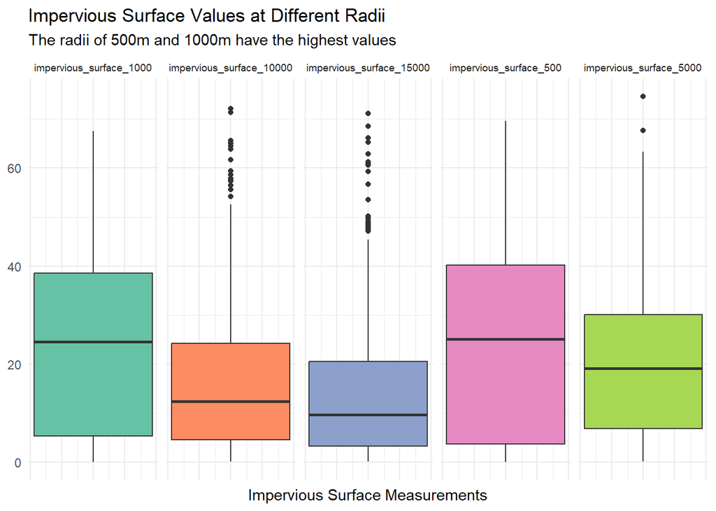

```r
pm_long |>
  ggplot(aes(y = impervious_surfaces_values, fill = impervious_surfaces)) +
  geom_boxplot() +
  facet_grid(. ~ impervious_surfaces, ) +
  labs(
    title = "Impervious Surface Values at Different Radii",
    subtitle = "The radii of 500m and 1000m have the highest values",
    x = "Impervious Surface Measurements"
  ) +
  scale_fill_brewer(palette = "Set2") +
  theme_minimal() +
  theme(
    strip.text.x = element_text(angle = 0, size = 7),
    axis.text.x = element_blank(),
    axis.title.y = element_blank(),
    legend.position = "none"
  )
```

It looks like the highest values are in the 500 meter radius while the lowest values are in the 15000 meter radius. This is possibly because in a larger radius there is more empty land that is measured than in the smaller radius.

For the road lengths, we’ll only be looking at the variables for primary roads only.

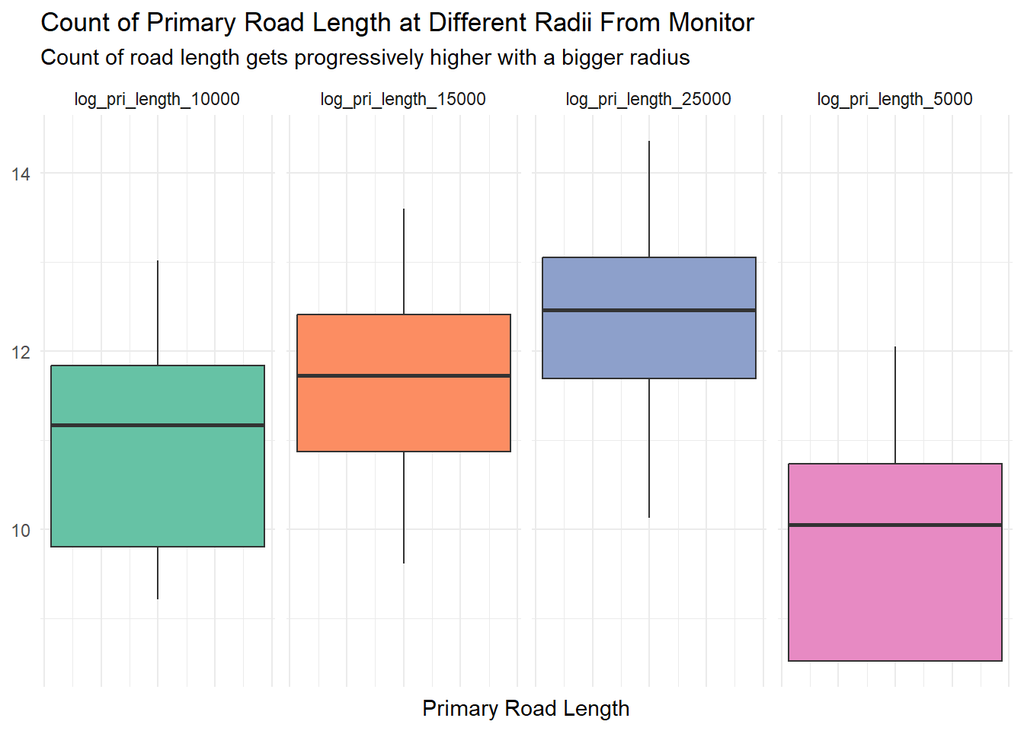

```r
pm_long |>
  ggplot(aes(y = pri_roads_values, fill = pri_roads)) +
  geom_boxplot() +
  facet_grid(. ~ pri_roads) +
  labs(
    title = "Count of Primary Road Length at Different Radii From Monitor",
    subtitle = "Count of road length gets progressively higher with a bigger radius",
    x = "Primary Road Length"
  ) +
  scale_fill_brewer(palette = "Set2") +
  theme_minimal() +
  theme(
    axis.text.x = element_blank(),
    axis.title.y = element_blank(),
    legend.position = "none"
  )
```

It looks like the count of road length gets higher as the radius around the monitor increases. This makes sense as the roads included in the 500 meter radius are also included in the 10000 meter radius.

The last set of variables we want to look at are the emissions variables.

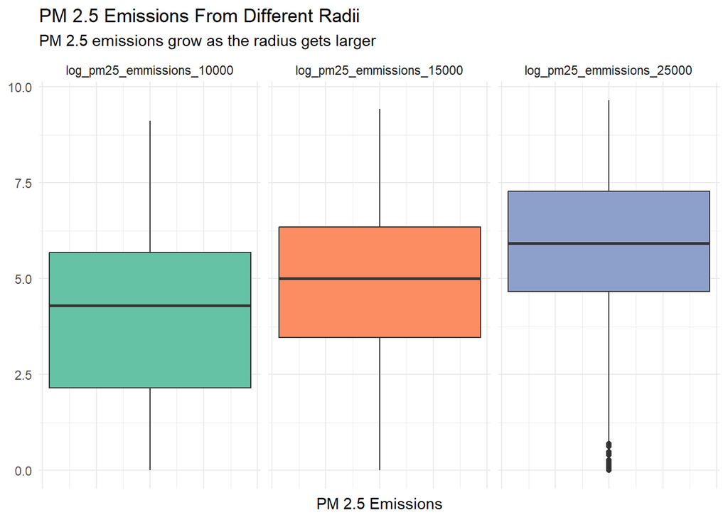

```r
pm_long |>
  filter(str_starts(pm_emissions, "log_pm25")) |>
  ggplot(aes(y = pm_emissions_values, fill = pm_emissions)) +
  geom_boxplot() +
  facet_grid(. ~ pm_emissions) +
  labs(
    title = "PM 2.5 Emissions From Different Radii",
    subtitle = "PM 2.5 emissions grow as the radius gets larger",
    x = "PM 2.5 Emissions"
  ) +
  scale_fill_brewer(palette = "Set2") +
  theme_minimal() +
  theme(
    axis.text.x = element_blank(),
    axis.title.y = element_blank(),
    legend.position = "none"
  )
```

Just like with the road length, the PM 2.5 emissions grow larger as the radius around the monitor gets larger. Again, this makes sense for the same reasons as with the road length. This might suggest that these types of variables are closely correlted within their groups.

Another thing that we saw with the skim output is that there are only 49 states. Why is that? Let’s find out

```r
pm |>
  distinct(state)
```

```
## # A tibble: 49 × 1
##    state
##    <chr>
##  1 Alabama
##  2 Arizona
##  3 Arkansas
##  4 California
##  5 Colorado
##  6 Connecticut
##  7 Delaware
##  8 District Of Columbia
##  9 Florida
## 10 Georgia
## # ℹ 39 more rows
```

Looking at the output, and knowing a little bit of American geography, we can see that Alaska and Hawaii aren’t included, but Washington DC is which explains why there are 49 “states”

Still working with the states, one thing that can affect the outcome of the model is how many monitors there are per state

```r
pm |> group_by(state) |>
  summarize(num_monitors = n()) |>
  arrange(desc(num_monitors))
```

```
## # A tibble: 49 × 2
##    state          num_monitors
##    <chr>                 <int>
##  1 California               85
##  2 Ohio                     44
##  3 Illinois                 38
##  4 Indiana                  36
##  5 North Carolina           35
##  6 Pennsylvania             32
##  7 Michigan                 30
##  8 Florida                  29
##  9 Georgia                  28
## 10 Texas                    27
## # ℹ 39 more rows
```

California clearly has the most amount of monitors, with Ohio in second with nearly half the number. On the other end, Maine only has 1 monitor.

Why does California have so many monitors? Maybe it’s because they have much higher pollution than other states? Let’s find out.

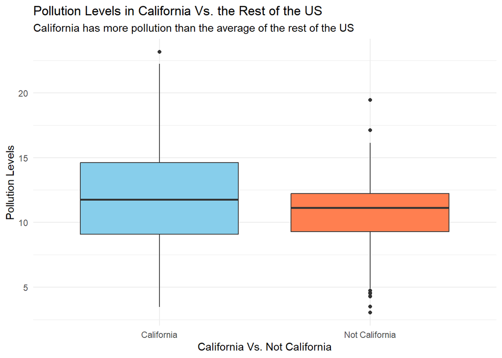

```r
pm <- pm |>
  mutate(cali = case_when(
    state == "California" ~ "California",
    state != "California" ~ "Not California"
  ))

pm |>
  ggplot(aes(x = cali, y = value, fill = cali)) +
  geom_boxplot() +
  labs(
    title = "Pollution Levels in California Vs. the Rest of the US",
    subtitle = "California has more pollution than the average of the rest of the US",
    x = "California Vs. Not California",
    y = "Pollution Levels"
  ) +
  theme_minimal() +
  scale_fill_manual(values = c("California" = "skyblue", "Not California" = "coral")) +
  theme(
    legend.position = "none"
  )
```

It looks like California, on average, does have more pollution than everywhere else in the US. However we can see that it also has more variability as the quantiles are more spred out.

California has the most monitors and also has higher than average pollution, so this begs the question if the number of monitors is correlated with the levels of pollution for other states as well.

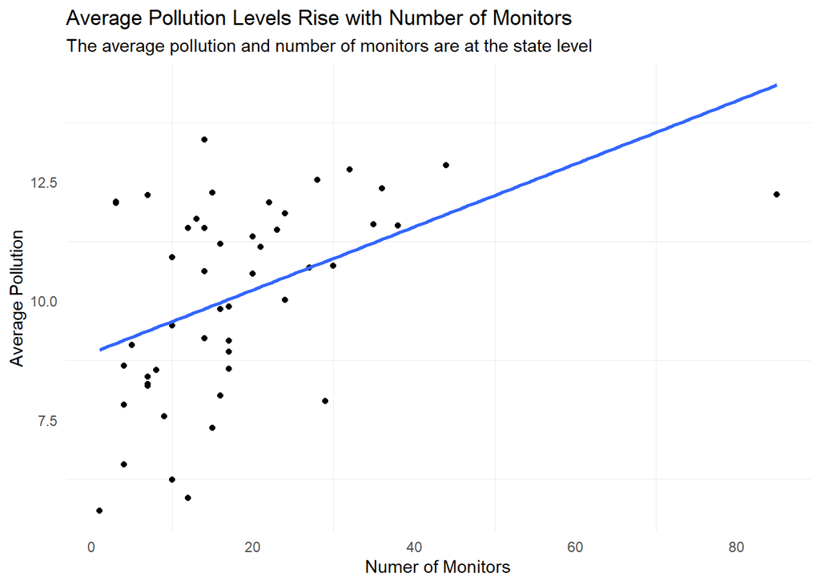

```r
pm_state <- pm |>
  group_by(state) |>
  summarize(num_monitors = n(), avg_pol = mean(value))

pm_state |>
  ggplot(aes(x = num_monitors, y = avg_pol)) +
  geom_point() +
  geom_smooth(method = "lm", se = FALSE) +
  labs(
    title = "Average Pollution Levels Rise with Number of Monitors",
    subtitle = "The average pollution and number of monitors are at the state level",
    x = "Numer of Monitors",
    y = "Average Pollution"
  ) +
  theme_minimal() +
  theme(
    panel.grid.major.x = element_blank(),
    panel.grid.major.y = element_blank()
  )
```

In this plot we can see that there is a definite positive relationship between the number of monitors and the average pollution. Without further analysis it is impossible to decide whether this is causal in any way, but it’s interesting to keep in mind nonetheless. Maybe states with more pollution receive more monitors?

We know that the number of monitors is correlated with the pollution level, but maybe there are some confounding variables that are pushing this correlation? One variable in the dataset that could help explain this is the population density of each county. Perhaps a higher population density results in more pollution?

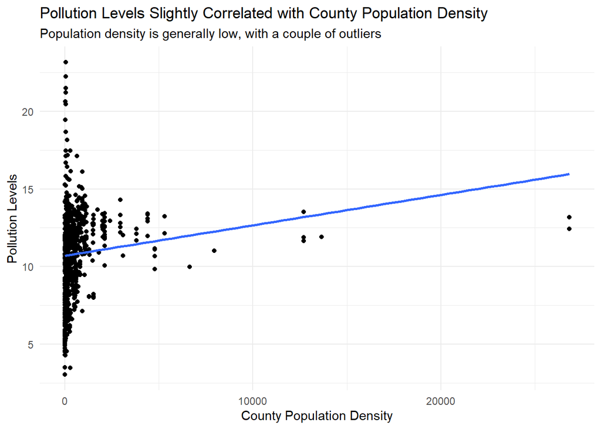

```r
pm |>
  ggplot(aes(x = popdens_county, y = value)) +
  geom_point() +
  geom_smooth(method = "lm", se = FALSE) +
  labs(
    title = "Pollution Levels Slightly Correlated with County Population Density",
    subtitle = "Population density is generally low, with a couple of outliers",
    x = "County Population Density",
    y = "Pollution Levels"
  ) +
  theme_minimal() +
  theme(

  )
```

It seems like there is a slight positive correlation, however most of the data points have very low population density so there’s no clear relationship.

The number of monitors in each state and the population density are only two variables that may have predictive power for pollution levels. Our dataset has ~50 variables that we can use, but it’s best if we can narrow that number down to only use the variables with the most predictive power. One way to do this is by looking at the correlation between the variables in our dataset. Variables that are highly correlated with each other may not add much predictive power, and may actually make the model worse.

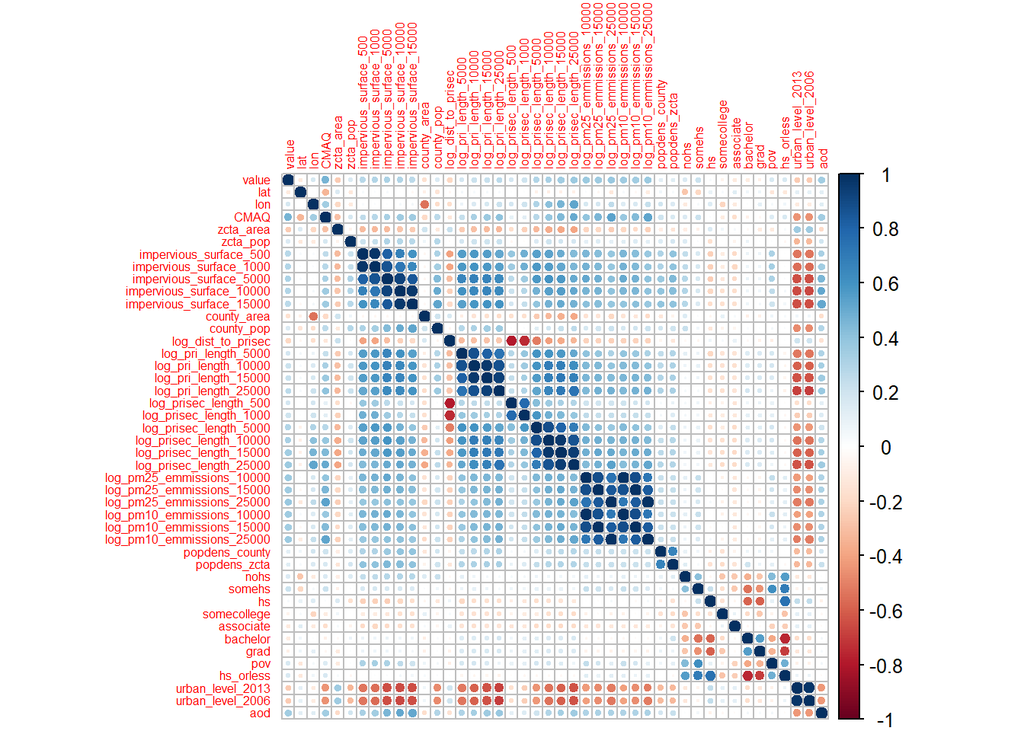

```r
PM_cor <- cor(pm |> dplyr::select_if(is.numeric))
corrplot::corrplot(PM_cor, tl.cex = 0.5)
```

We can see from the table that the development variables, road density variables, and pollution measurement variables are all related within each group, but just how correlated are they?

First we’ll look at the development variables (imp)

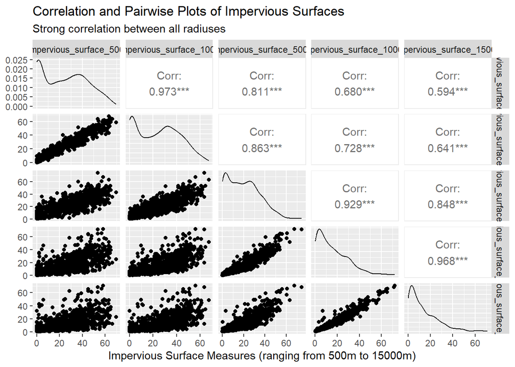

```r
select(pm, contains("imp")) |>
  GGally::ggpairs() +
  labs(
    title = "Correlation and Pairwise Plots of Impervious Surfaces",
    subtitle = "Strong correlation between all radiuses",
    x = "Impervious Surface Measures (ranging from 500m to 15000m)"
  )
```

Now let’s look at the road density variables

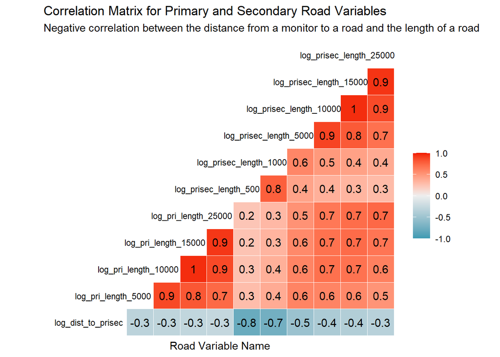

```r
select(pm, contains("pri")) |>
  GGally::ggcorr(hjust = .85, size = 3,
       layout.exp=2, label = TRUE) +
  labs(
    title = "Correlation Matrix for Primary and Secondary Road Variables",
    subtitle = "Negative correlation between the distance from a monitor to a road and the length of a road",
    x = "Road Variable Name"
  )
```

From this table we can see that the distance from a monitor to a primary or secondary road is negatively correlated with the road length variables, which makes sense. If the distance is higher, then that means there are less roads in the area.

Finally, let’s look at the emmissions variables.

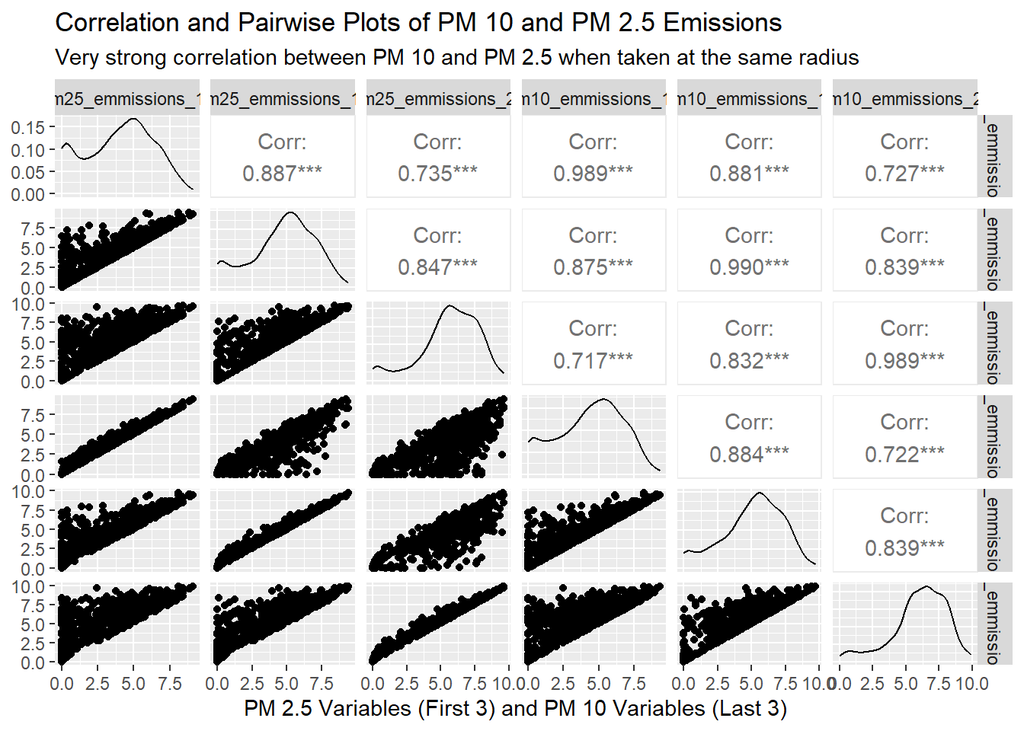

```r
select(pm, contains("pm")) |>
  GGally::ggpairs() +
  labs(
    title = "Correlation and Pairwise Plots of PM 10 and PM 2.5 Emissions",
    subtitle = "Very strong correlation between PM 10 and PM 2.5 when taken at the same radius",
    x = "PM 2.5 Variables (First 3) and PM 10 Variables (Last 3)"
  )
```

Again we see the same pattern as with the development variables. They’re all very positively correlated with each other, but the variables that share the same radius of measurement have the highest correlation (near perfect)

So we know that all of those variables are correlated within each other, but how about between each other?

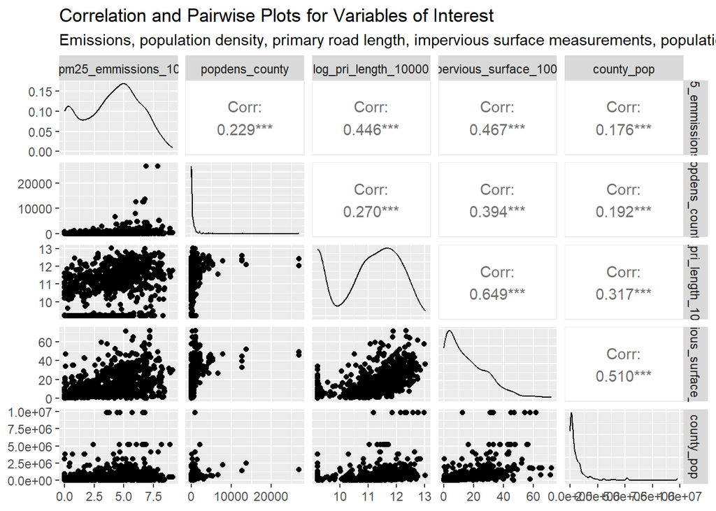

```r
pm |>
select(log_pm25_emmissions_10000, popdens_county,
       log_pri_length_10000, impervious_surface_10000, county_pop) |>
  GGally::ggpairs() +
  labs(
    title = "Correlation and Pairwise Plots for Variables of Interest",
    subtitle = "Emissions, population density, primary road length, impervious surface measurements, population"
  )
```

We can see that the groups generally aren’t very correlated with one another. The development marker and the road length marker at a radius of 10,000 meters are the most correlated, with a correlation coefficient of .649.

## Analysis

```r
# Converting to factors
pm <- pm |>
  mutate(across(c(id, fips, zcta), as.factor))
```

### Data Splitting

```r
pm <- pm |>
  mutate(city = case_when(city == "Not in a city" ~ "Not in a city",
                          city != "Not in a city" ~ "In a city"))

set.seed(1234) # same seed as before
pm_split <- rsample::initial_split(data = pm, prop = 2/3)
pm_split
```

```
## <Training/Testing/Total>
## <584/292/876>
```

```r
train_pm <- rsample::training(pm_split)
test_pm <- rsample::testing(pm_split)
```

### Initial Model

```r
RF_rec <- recipe(train_pm) |>
    update_role(everything(), new_role = "predictor")|>
    update_role(value, new_role = "outcome")|>
    update_role(id, new_role = "id variable") |>
    update_role("fips", new_role = "county id") |>
    step_novel("state") |>
    step_string2factor("state", "county", "city") |>
    step_rm("county") |>
    step_rm("zcta") |>
    step_corr(all_numeric())|>
    step_nzv(all_numeric())
```

```r
RF_PM_model <- parsnip::rand_forest(mtry = 10, min_n = 3) |>
  set_engine("randomForest") |>
  set_mode("regression")

RF_PM_model
```

```
## Random Forest Model Specification (regression)
##
## Main Arguments:
##   mtry = 10
##   min_n = 3
##
## Computational engine: randomForest
```

```r
RF_wflow <- workflows::workflow() |>
  workflows::add_recipe(RF_rec) |>
  workflows::add_model(RF_PM_model)

RF_wflow
```

```
## ══ Workflow ════════════════════════════════════════════════════════════════════
## Preprocessor: Recipe
## Model: rand_forest()
##
## ── Preprocessor ────────────────────────────────────────────────────────────────
## 6 Recipe Steps
##
## • step_novel()
## • step_string2factor()
## • step_rm()
## • step_rm()
## • step_corr()
## • step_nzv()
##
## ── Model ───────────────────────────────────────────────────────────────────────
## Random Forest Model Specification (regression)
##
## Main Arguments:
##   mtry = 10
##   min_n = 3
##
## Computational engine: randomForest
```

```r
RF_wflow_fit <- parsnip::fit(RF_wflow, data = train_pm)

RF_wflow_fit
```

```
## ══ Workflow [trained] ══════════════════════════════════════════════════════════
## Preprocessor: Recipe
## Model: rand_forest()
##
## ── Preprocessor ────────────────────────────────────────────────────────────────
## 6 Recipe Steps
##
## • step_novel()
## • step_string2factor()
## • step_rm()
## • step_rm()
## • step_corr()
## • step_nzv()
##
## ── Model ───────────────────────────────────────────────────────────────────────
##
## Call:
##  randomForest(x = maybe_data_frame(x), y = y, mtry = min_cols(~10,      x), nodesize = min_rows(~3, x))
##                Type of random forest: regression
##                      Number of trees: 500
## No. of variables tried at each split: 10
##
##           Mean of squared residuals: 2.700411
##                     % Var explained: 58.26
```

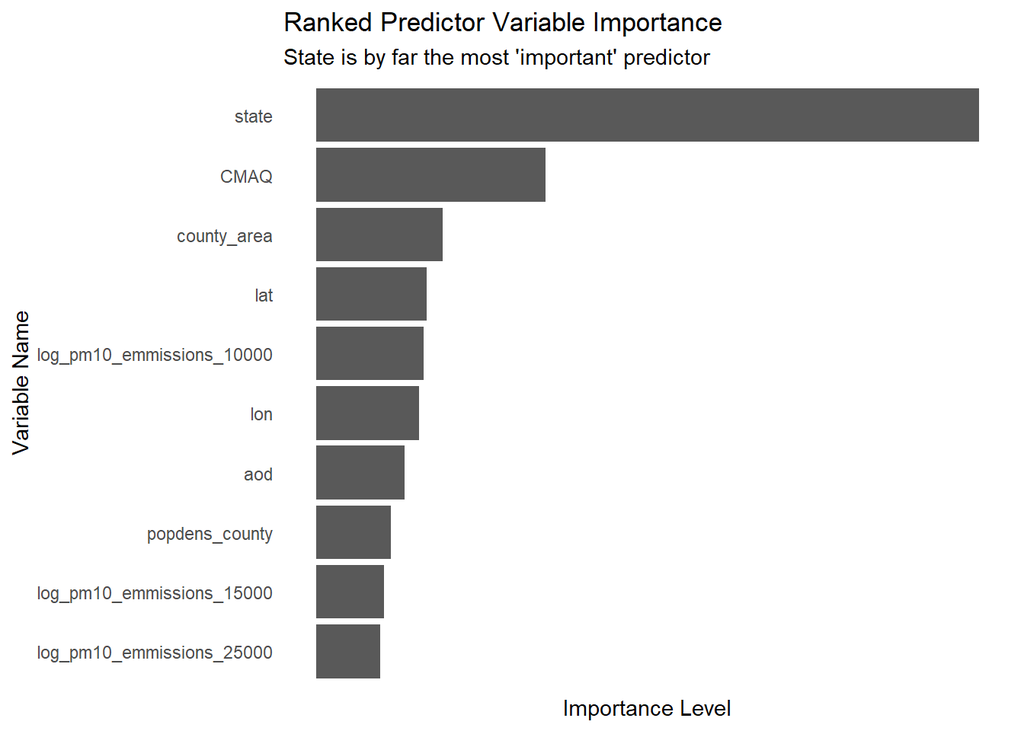

```r
RF_wflow_fit |>
  extract_fit_parsnip() |>
  vip::vip(num_features = 10) +
  labs(
    title = "Ranked Predictor Variable Importance",
    subtitle = "State is by far the most 'important' predictor",
    y = "Importance Level",
    x = "Variable Name"
  ) +
  theme_minimal() +
  theme(
    axis.text.x = element_blank(),
    panel.grid.major = element_blank(),
    panel.grid.minor = element_blank()
  )
```

Here we see that the state is the most important variable for determining pollution levels. As we saw in an earlier plot, California had on average higher pollution than the other states, so maybe a state being California or not is a large predictor.

### Implementing Cross-Validation

While our model is usable, it can be improved on pretty easily. One way to do this is by using cross-validation to ensure less overfitting by the model on the training data.

```r
set.seed(1234)
vfold_pm <- rsample::vfold_cv(data = train_pm, v = 4)
pull(vfold_pm, splits)
```

```
## [[1]]
## <Analysis/Assess/Total>
## <438/146/584>
##
## [[2]]
## <Analysis/Assess/Total>
## <438/146/584>
##
## [[3]]
## <Analysis/Assess/Total>
## <438/146/584>
##
## [[4]]
## <Analysis/Assess/Total>
## <438/146/584>
```

```r
set.seed(456)
resample_RF_fit <- tune::fit_resamples(RF_wflow, vfold_pm)
collect_metrics(resample_RF_fit)
```

```
## # A tibble: 2 × 6
##   .metric .estimator  mean     n std_err .config
##   <chr>   <chr>      <dbl> <int>   <dbl> <chr>
## 1 rmse    standard   1.67      4  0.109  Preprocessor1_Model1
## 2 rsq     standard   0.587     4  0.0563 Preprocessor1_Model1
```

Looking at the RMSE now, we can see that it’s dropped by a lot (relative to the size of it before cross-validation). On the other hand, the R-squared has only increased minimally, by roughly .06 percentage points.

Using cross-validation is a step in the right direction, but we can take this even further by tuning the hyperparameters as well.

### Tuning Our Hyperparameters

```r
tune_RF_model <- rand_forest(mtry = tune(), min_n = tune()) |>
  set_engine("randomForest") |>
  set_mode("regression")

tune_RF_model
```

```
## Random Forest Model Specification (regression)
##
## Main Arguments:
##   mtry = tune()
##   min_n = tune()
##
## Computational engine: randomForest
```

Now let’s create the worflow using the tuned model

```r
RF_tune_wflow <- workflows::workflow() |>
  workflows::add_recipe(RF_rec) |>
  workflows::add_model(tune_RF_model)

RF_tune_wflow
```

```
## ══ Workflow ════════════════════════════════════════════════════════════════════
## Preprocessor: Recipe
## Model: rand_forest()
##
## ── Preprocessor ────────────────────────────────────────────────────────────────
## 6 Recipe Steps
##
## • step_novel()
## • step_string2factor()
## • step_rm()
## • step_rm()
## • step_corr()
## • step_nzv()
##
## ── Model ───────────────────────────────────────────────────────────────────────
## Random Forest Model Specification (regression)
##
## Main Arguments:
##   mtry = tune()
##   min_n = tune()
##
## Computational engine: randomForest
```

We’ll use all of the cores we have available in order to tune the model the fastest

```r
n_cores <- parallel::detectCores()
n_cores
```

```
## [1] 12
```

```r
doParallel::registerDoParallel(cores = n_cores)

set.seed(123)
tune_RF_results <- tune_grid(object = RF_tune_wflow, resamples = vfold_pm, grid = 20)
tune_RF_results
```

```
## # Tuning results
## # 4-fold cross-validation
## # A tibble: 4 × 4
##   splits            id    .metrics          .notes
##   <list>            <chr> <list>            <list>
## 1 <split [438/146]> Fold1 <tibble [40 × 6]> <tibble [0 × 3]>
## 2 <split [438/146]> Fold2 <tibble [40 × 6]> <tibble [0 × 3]>
## 3 <split [438/146]> Fold3 <tibble [40 × 6]> <tibble [1 × 3]>
## 4 <split [438/146]> Fold4 <tibble [40 × 6]> <tibble [0 × 3]>
##
## There were issues with some computations:
##
##   - Warning(s) x1: 37 columns were requested but there were 36 predictors in the dat...
##
## Run `show_notes(.Last.tune.result)` for more information.
```

```r
tune_RF_results |>
  collect_metrics()
```

```
## # A tibble: 40 × 8
##     mtry min_n .metric .estimator  mean     n std_err .config
##    <int> <int> <chr>   <chr>      <dbl> <int>   <dbl> <chr>
##  1    13    33 rmse    standard   1.72      4  0.0968 Preprocessor1_Model01
##  2    13    33 rsq     standard   0.559     4  0.0538 Preprocessor1_Model01
##  3    28    35 rmse    standard   1.69      4  0.102  Preprocessor1_Model02
##  4    28    35 rsq     standard   0.561     4  0.0502 Preprocessor1_Model02
##  5    23    40 rmse    standard   1.70      4  0.103  Preprocessor1_Model03
##  6    23    40 rsq     standard   0.557     4  0.0522 Preprocessor1_Model03
##  7     1    27 rmse    standard   2.03      4  0.0566 Preprocessor1_Model04
##  8     1    27 rsq     standard   0.449     4  0.0316 Preprocessor1_Model04
##  9     6    32 rmse    standard   1.76      4  0.0817 Preprocessor1_Model05
## 10     6    32 rsq     standard   0.556     4  0.0490 Preprocessor1_Model05
## # ℹ 30 more rows
```

```r
show_best(tune_RF_results, metric = "rmse", n = 1)
```

```
## # A tibble: 1 × 8
##    mtry min_n .metric .estimator  mean     n std_err .config
##   <int> <int> <chr>   <chr>      <dbl> <int>   <dbl> <chr>
## 1    31     4 rmse    standard    1.65     4   0.116 Preprocessor1_Model16
```

```r
tuned_RF_values <- select_best(tune_RF_results, metric = "rmse")
tuned_RF_values
```

```
## # A tibble: 1 × 3
##    mtry min_n .config
##   <int> <int> <chr>
## 1    31     4 Preprocessor1_Model16
```

```r
# specify best combination from tune in workflow
RF_tuned_wflow <-RF_tune_wflow |>
  tune::finalize_workflow(tuned_RF_values)

# fit model with those parameters on train AND test
overallfit <- RF_wflow |>
  tune::last_fit(pm_split)

collect_metrics(overallfit)
```

```
## # A tibble: 2 × 4
##   .metric .estimator .estimate .config
##   <chr>   <chr>          <dbl> <chr>
## 1 rmse    standard       1.72  Preprocessor1_Model1
## 2 rsq     standard       0.604 Preprocessor1_Model1
```

Now that we’ve predicted our test data, let’s gather all of the predictions so we can use them later.

```r
test_predictions <- collect_predictions(overallfit)
```

### Plotting the model prediction result

We have our predictions and a metric for determining it’s accuracy, but it would be easier if we could visualize how accurate our model is. In order to do this we will need to plot the geographical data of our monitors as well as our predictions.

```r
library(sf)
library(maps)
library(rnaturalearth)
```

Here is a world map that we will be building off of.

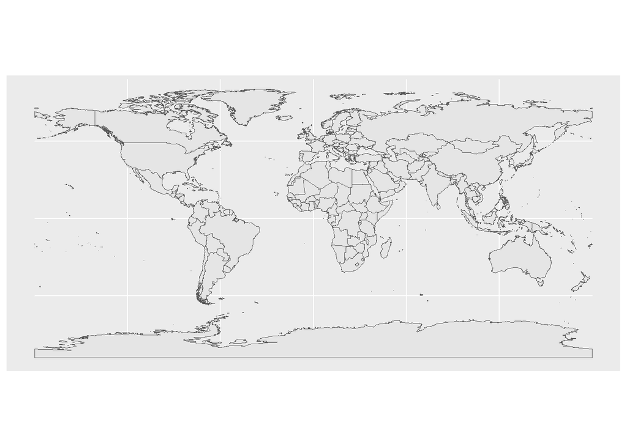

```r
world <- ne_countries(scale = "medium", returnclass = "sf")

ggplot(data = world) +
    geom_sf()
```

Our data is only in the US, so let’s narrow down our map to just the continental US.

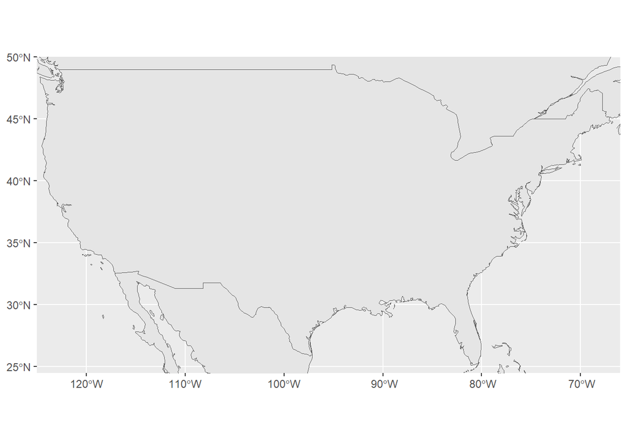

```r
ggplot(data = world) +
    geom_sf() +
    coord_sf(xlim = c(-125, -66), ylim = c(24.5, 50),
             expand = FALSE)
```

We’ve narrowed down the map to just the continental US, but we still want to see where our monitors are on the map.

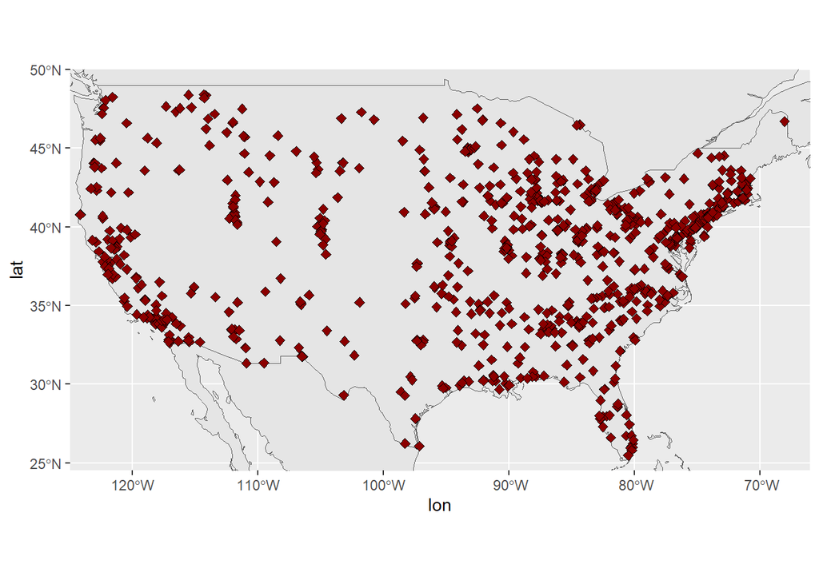

```r
ggplot(data = world) +
    geom_sf() +
    coord_sf(xlim = c(-125, -66), ylim = c(24.5, 50),
             expand = FALSE)+
    geom_point(data = pm, aes(x = lon, y = lat), size = 2,
               shape = 23, fill = "darkred")
```

Our data is also separated by county, so let’s add the county lines as well.

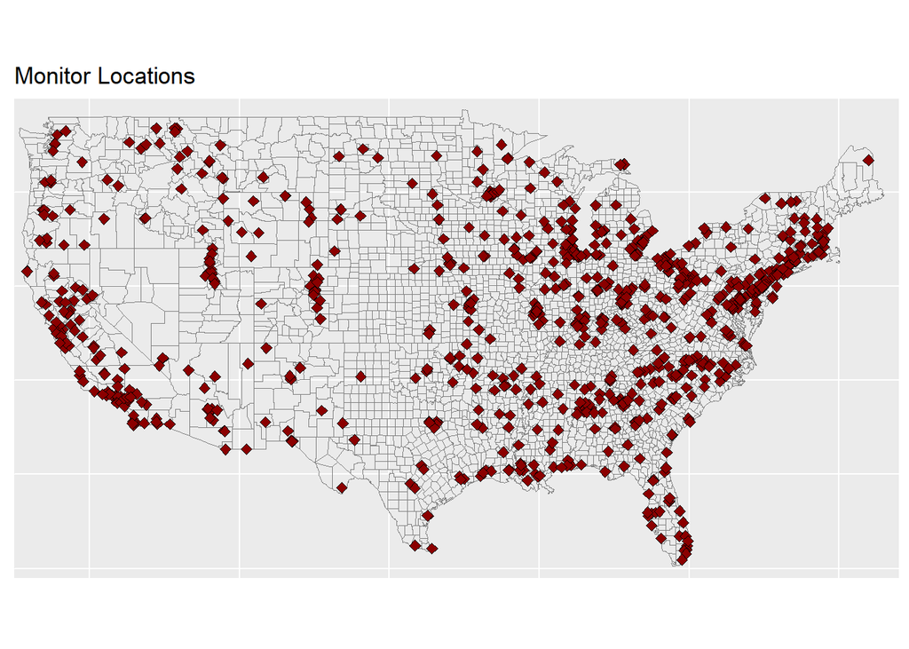

```r
counties <- sf::st_as_sf(maps::map("county", plot = FALSE,
                                   fill = TRUE))

monitors <- ggplot(data = world) +
    geom_sf(data = counties, fill = NA, color = gray(.5))+
      coord_sf(xlim = c(-125, -66), ylim = c(24.5, 50),
             expand = FALSE) +
    geom_point(data = pm, aes(x = lon, y = lat), size = 2,
               shape = 23, fill = "darkred") +
    ggtitle("Monitor Locations") +
    theme(axis.title.x=element_blank(),
          axis.text.x = element_blank(),
          axis.ticks.x = element_blank(),
          axis.title.y = element_blank(),
          axis.text.y = element_blank(),
          axis.ticks.y = element_blank())

monitors
```

Before we move on, we need to wrangle the data a little bit more in order to make the plots work.

```r
counties <- counties |>
  tidyr::separate(ID, into = c("state", "county"), sep = ",") |>
  dplyr::mutate(county = stringr::str_to_title(county))

map_data <- dplyr::inner_join(counties, pm, by = "county")
```

Now we can plot the actual pollution levels vs. our predicted pollution levels.

First, the ground truth levels.

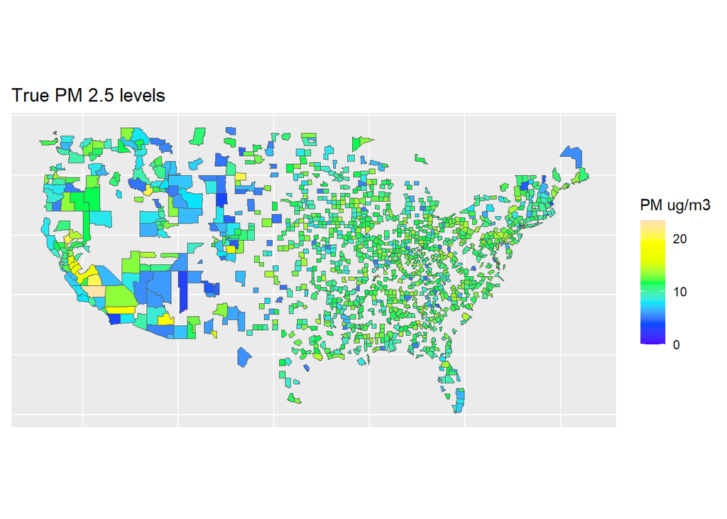

```r
truth <- ggplot(data = world) +
  coord_sf(xlim = c(-125,-66),
           ylim = c(24.5, 50),
           expand = FALSE) +
  geom_sf(data = map_data, aes(fill = value)) +
  scale_fill_gradientn(colours = topo.colors(7),
                       na.value = "transparent",
                       breaks = c(0, 10, 20),
                       labels = c(0, 10, 20),
                       limits = c(0, 23.5),
                       name = "PM ug/m3") +
  ggtitle("True PM 2.5 levels") +
  theme(axis.title.x = element_blank(),
        axis.text.x = element_blank(),
        axis.ticks.x = element_blank(),
        axis.title.y = element_blank(),
        axis.text.y = element_blank(),
        axis.ticks.y = element_blank())

truth
```

And now the predicted data. First, we need to get the data.

```r
# fit data
RF_final_train_fit <- parsnip::fit(RF_tuned_wflow, data = train_pm)
RF_final_test_fit <- parsnip::fit(RF_tuned_wflow, data = test_pm)

# get predictions on training data
values_pred_train <- predict(RF_final_train_fit, train_pm) |>
  bind_cols(train_pm |> select(value, fips, county, id))

# get predictions on testing data
values_pred_test <- predict(RF_final_test_fit, test_pm) |>
  bind_cols(test_pm |> select(value, fips, county, id))
values_pred_test
```

```
## # A tibble: 292 × 5
##    .pred value fips  county     id
##    <dbl> <dbl> <fct> <chr>      <fct>
##  1  11.5  11.2 1033  Colbert    1033.1002
##  2  12.1  12.4 1055  Etowah     1055.001
##  3  11.0  10.5 1069  Houston    1069.0003
##  4  14.3  15.6 1073  Jefferson  1073.0023
##  5  12.2  12.4 1073  Jefferson  1073.1005
##  6  11.3  11.1 1073  Jefferson  1073.1009
##  7  11.6  11.8 1073  Jefferson  1073.5003
##  8  10.8  10.0 1097  Mobile     1097.0003
##  9  12.0  12.0 1101  Montgomery 1101.0007
## 10  12.8  13.2 1113  Russell    1113.0001
## # ℹ 282 more rows
```

```r
# combine
all_pred <- bind_rows(values_pred_test, values_pred_train)
```

And now we can plot it.

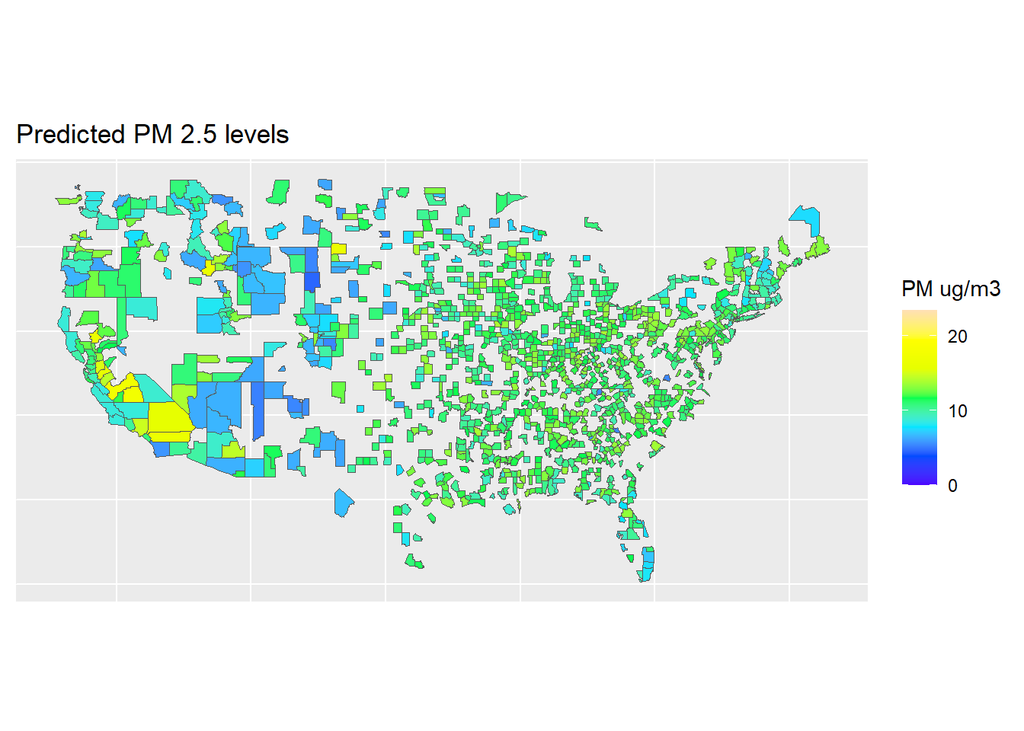

```r
map_data <- inner_join(counties, all_pred, by = "county")

pred <- ggplot(data = world) +
  coord_sf(xlim = c(-125,-66),
           ylim = c(24.5, 50),
           expand = FALSE) +
  geom_sf(data = map_data, aes(fill = .pred)) +
  scale_fill_gradientn(colours = topo.colors(7),
                       na.value = "transparent",
                       breaks = c(0, 10, 20),
                       labels = c(0, 10, 20),
                       limits = c(0, 23.5),
                       name = "PM ug/m3") +
  ggtitle("Predicted PM 2.5 levels") +
  theme(axis.title.x=element_blank(),
        axis.text.x=element_blank(),
        axis.ticks.x=element_blank(),
        axis.title.y=element_blank(),
        axis.text.y=element_blank(),
        axis.ticks.y=element_blank())

pred
```

Now that we have both plots, let’s look at them against each other.

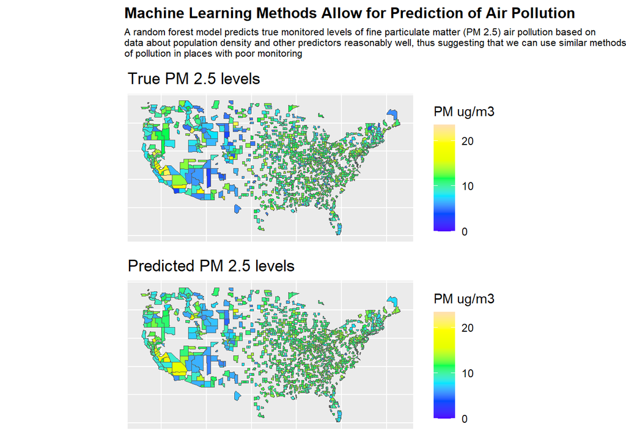

```r
library(patchwork)

final_plot <- (truth/pred) +
  plot_annotation(title = "Machine Learning Methods Allow for Prediction of Air Pollution", subtitle = "A random forest model predicts true monitored levels of fine particulate matter (PM 2.5) air pollution based on\ndata about population density and other predictors reasonably well, thus suggesting that we can use similar methods to predict levels\nof pollution in places with poor monitoring",
                  theme = theme(plot.title = element_text(size =12, face = "bold"),
                                plot.subtitle = element_text(size = 8)))

final_plot
```

It looks like our Random Forest model is predicting the pollution for each available county across the US very well. There is some variation, but that is expected. Overall it seems like our model is more than accurate enough. However, are there ways we can improve this?

## Extension Question

For our extension question, we want to know if there is a difference with how our model performs with high population density and low population density counties, as well as if a linear model might be better for that task. We’ll start by separating our dataset into a high population density dataset and a low population density dataset.

```r
median_popdens = median(pm$popdens_county, na.rm = TRUE)

# Split into high and low population density
high_density <- pm |> filter(popdens_county > median_popdens)
low_density <- pm |> filter(popdens_county <= median_popdens)

# Check the number of rows in each group
cat("High Density Counties:", nrow(high_density), "\n")
```

```
## High Density Counties: 437
```

```r
cat("Low Density Counties:", nrow(low_density), "\n")
```

```
## Low Density Counties: 439
```

There are a very even number of observations in each dataset, so that won’t be a problem for analysis.

```r
# Fit a linear regression model for high population density counties
lm_high <- lm(CMAQ ~ popdens_county + impervious_surface_1000 + log_pm25_emmissions_10000, data = high_density)

# Fit a linear regression model for low population density counties
lm_low <- lm(CMAQ ~ popdens_county + impervious_surface_1000 + log_pm25_emmissions_10000, data = low_density)

# Summarize the models
summary(lm_high)
```

```
##
## Call:
## lm(formula = CMAQ ~ popdens_county + impervious_surface_1000 +
##     log_pm25_emmissions_10000, data = high_density)
##
## Residuals:
##     Min      1Q  Median      3Q     Max
## -6.7879 -1.4324  0.0328  1.3725  8.2369
##
## Coefficients:
##                             Estimate Std. Error t value Pr(>|t|)
## (Intercept)                7.824e+00  3.208e-01  24.391  < 2e-16 ***
## popdens_county             9.586e-05  5.009e-05   1.914   0.0563 .
## impervious_surface_1000   -1.038e-02  7.444e-03  -1.394   0.1640
## log_pm25_emmissions_10000  4.272e-01  6.039e-02   7.074 6.08e-12 ***
## ---
## Signif. codes:  0 '***' 0.001 '**' 0.01 '*' 0.05 '.' 0.1 ' ' 1
##
## Residual standard error: 2.316 on 433 degrees of freedom
## Multiple R-squared:  0.1251, Adjusted R-squared:  0.119
## F-statistic: 20.64 on 3 and 433 DF,  p-value: 1.627e-12
```

```r
summary(lm_low)
```

```
##
## Call:
## lm(formula = CMAQ ~ popdens_county + impervious_surface_1000 +
##     log_pm25_emmissions_10000, data = low_density)
##
## Residuals:
##     Min      1Q  Median      3Q     Max
## -5.0593 -1.9292 -0.0672  1.4875 17.3039
##
## Coefficients:
##                            Estimate Std. Error t value Pr(>|t|)
## (Intercept)                5.482183   0.236371  23.193  < 2e-16 ***
## popdens_county             0.024448   0.003175   7.699 9.29e-14 ***
## impervious_surface_1000   -0.021096   0.009623  -2.192 0.028894 *
## log_pm25_emmissions_10000  0.215371   0.059693   3.608 0.000344 ***
## ---
## Signif. codes:  0 '***' 0.001 '**' 0.01 '*' 0.05 '.' 0.1 ' ' 1
##
## Residual standard error: 2.668 on 435 degrees of freedom
## Multiple R-squared:  0.1883, Adjusted R-squared:  0.1827
## F-statistic: 33.63 on 3 and 435 DF,  p-value: < 2.2e-16
```

The RMSE for the high population density data is 2.32 and the RMSE for the low population density data is 2.67. This is a relatively large difference between them, which implies that one model might not be sufficient.

```r
# Extract predictions for high-density and low-density groups
rf_pred_high <- predict(overallfit$.workflow[[1]], new_data = high_density) |>
  bind_cols(high_density$value) |>
  rename(value = "...2")

rf_pred_low <- predict(overallfit$.workflow[[1]], new_data = low_density) |>
  bind_cols(low_density$value) |>
  rename(value = "...2")
```

```r
rf_pred_high |>
  rmse(truth = value, estimate = .pred)
```

```
## # A tibble: 1 × 3
##   .metric .estimator .estimate
##   <chr>   <chr>          <dbl>
## 1 rmse    standard       0.768
```

```r
rf_pred_low |>
  rmse(truth = value, estimate = .pred)
```

```
## # A tibble: 1 × 3
##   .metric .estimator .estimate
##   <chr>   <chr>          <dbl>
## 1 rmse    standard        1.38
```

[figure not shown]

```r
# Visualization: RMSE Comparison
# Create a data frame for visualization
rmse_data <- data.frame(
  Model = c("Linear Regression", "Linear Regression", "Random Forest", "Random Forest"),
  Density = c("High Density", "Low Density", "High Density", "Low Density"),
  RMSE = c(2.305, 2.655, 0.785, 1.380)
)

# Plot the RMSE values
ggplot(rmse_data, aes(x = Density, y = RMSE, fill = Model)) +
  geom_bar(stat = "identity", position = "dodge") +
  labs(title = "RMSE Comparison by Model and Population Density",
       x = "Population Density",
       y = "RMSE",
       fill = "Model") +
  theme_minimal()
```

## Results & Discussion

### Exploratory Data Analysis (EDA)

The Exploratory Data Analysis (EDA) revealed key insights into the distribution of air pollution levels (PM2.5 concentrations) and their relationship with various predictors across the U.S. The data consisted of 876 observations and 50 variables, with no missing values. California emerged as a standout state with the highest number of monitors and higher pollution levels compared to other states, demonstrating greater variability in pollution levels within the state.

We observe a positive correlation between the number of monitors in a state and the average pollution levels, suggesting that monitoring intensity may be higher in more polluted areas. Population density showed a slight positive correlation with pollution levels, but the relationship was weak, with most counties having low population density. Variables related to impervious surfaces, road lengths, and emissions were highly correlated within their respective groups, indicating potential redundancy. Interestingly, educational attainment variables exhibited minimal correlation with other predictors, suggesting a limited role in explaining pollution levels.

### Main Question

Visual comparisons between predicted and observed PM2.5 levels revealed that the Random Forest model effectively captured spatial patterns of air pollution across the U.S, with minimal discrepancies in most regions. However, areas with sparse monitoring data exhibited greater prediction errors, emphasizing the potential benefits of incorporating additional localized data to improve accuracy.

### Extension Question

To explore the relationship between population density and prediction accuracy, we further divided into high- and low-density counties using the median population density as a threshold, which allowed for a targeted analysis of model performance across differing demographic and environmental contexts.

## Conclusion

However, this study has limitations. The variability in model performance across population density groups suggests that a single model may not capture all regional complexities equally. Areas with sparse monitoring data remain a challenge, as the lack of localized information can lead to greater prediction errors. Additionally, while the Random Forest model demonstrated strong overall performance, further exploration of feature selection and alternative modeling approaches could enhance predictive accuracy, particularly in low-density regions. Future research should focus on integrating additional localized data, such as weather patterns or real-time emissions, to further refine model predictions. Furthermore, the development of density-specific or region-specific models could address the observed disparities in accuracy, ensuring more reliable predictions across diverse environments.

## References

Ellis, Shannon. (2024, November 5). 09-cs02-intro [Lecture]. University of California-San Diego, San Diego, CA, USA. https://cogs137-fa24.github.io/cogs137-fa24/content/lectures/09-cs02-intro.html#still-an-issue

https://www.epa.gov/pm-pollution/particulate-matter-pm-basics https://www.frontiersin.org/journals/public-health/articles/10.3389/fpubh.2020.00014/full https://www.opencasestudies.org/ocs-bp-air-pollution/